# Trabalho - cadeira de Séries Temporais

Parte 2 - EDA série temporal

Pedro Miguel Sousa Magalhães

2021-11-10

# Dataset description and initial transformations

This report explores data containing daily number of calls received by a multinational customer support center. Data extracted from real world operations and includes observations since 2017-01-01 until 2018-11-30. No further contextual information is know or provided which could impact the analysis of the present time series. No seasonality is inherent to the business and product for which the call center provides support. It is know that the number of countries/regions covered increased during the interval in analysis.

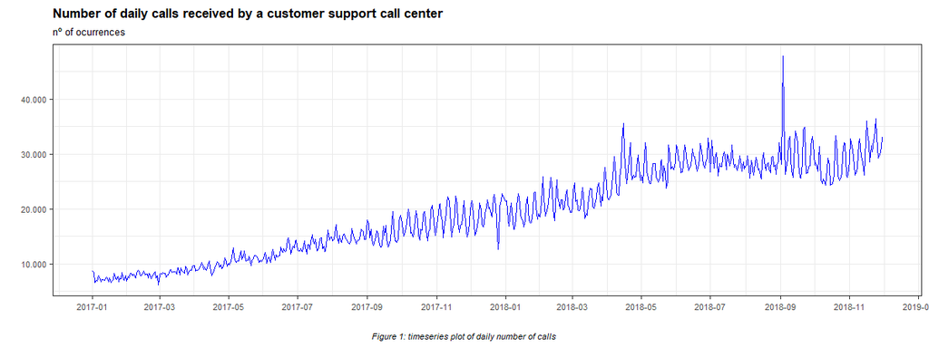

From a quick look at *Figure 1* some elements stand out:

- the data shows a clear upward trend with a positive linear relationship despite a upward shift around May 2018.
- the variance increases as time progresses leading to the conclusion that the random variable is **heteroscedastic** (using only visual process).
- the dataset contains a clear outliers specially around April and September 2018.

## Dealing with outliers

Outliers can affect the outcome of the analysis and impact the detrending process. Given that no information about operation was given which could help identify a outlier or better characterize then, they were removed using statistical methods. For this analysis the `tsoutlier()` and `tsclean()` functions of the `forecast` package was used to identify outliers and replace then using linear interpolation. *Figure 2* shows the impact of this transformation.

```
           total_calls
2018-04-15       35607
2018-09-03       47906
2018-09-04       36738
```

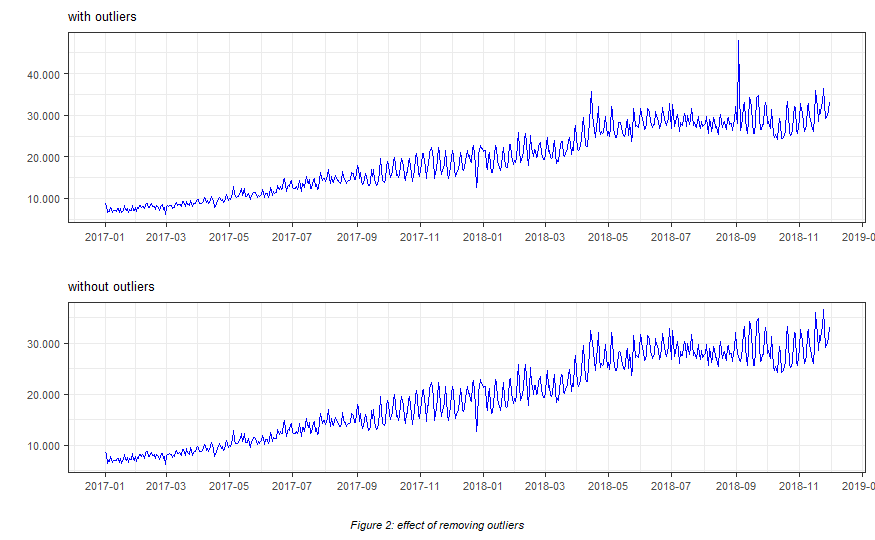

## Dealing with heterostacity

The assumption of homoscedasticity is key in many classical models (linear regression) and impacts the analysis. There is limited information for understanding the causes for the increase variation although, as was pointed out in the beginning, the increase number of regions might help explain this behavior (as number of location increases so does the difference between quiet and busy days).

Since the optimal lambda for BoxCox transformation is close to zero (estimated using Guerrero’s method and returning -0.22578) a simple log transformation was used for simplicity. *Figure 3* illustrates the impact of this transformation.

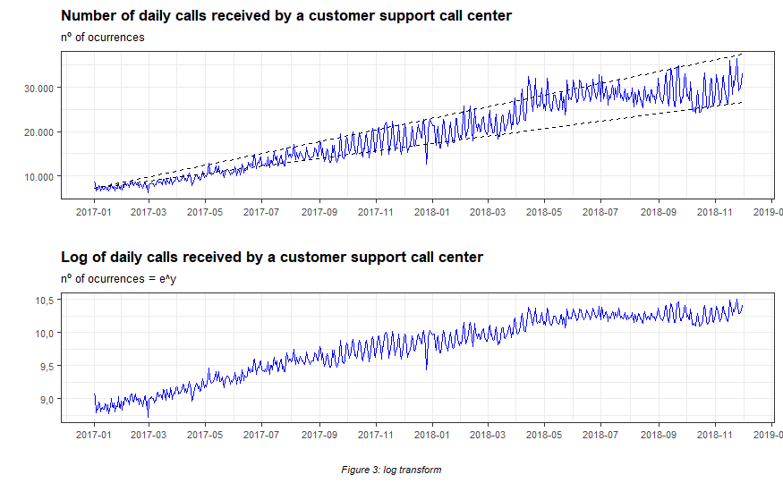

# Trend

As it is easily apparent from the plots above, the series under study presents a regular pattern with increasing variance. On one hand it suggests that a weekly season might exist but in other hand it makes it harder to analyse the underlying longer trend upward.

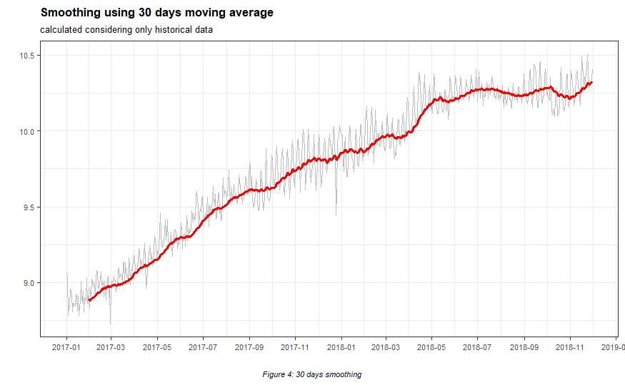

Using the 30 days moving average ( ~ 30 days before ) the underlying trend becomes more apparent *Figure 4.*. Despite a shift or acceleration around April/May 2018, the trend seems to follow a quadratic function more than a linear relation given the apparent plateau June and October.

## Detrending using first difference

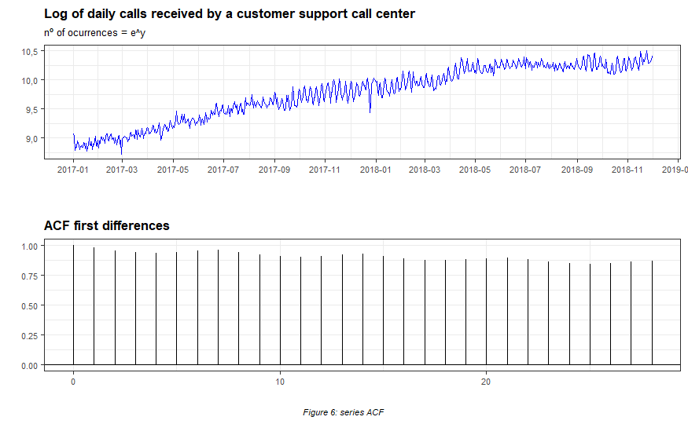

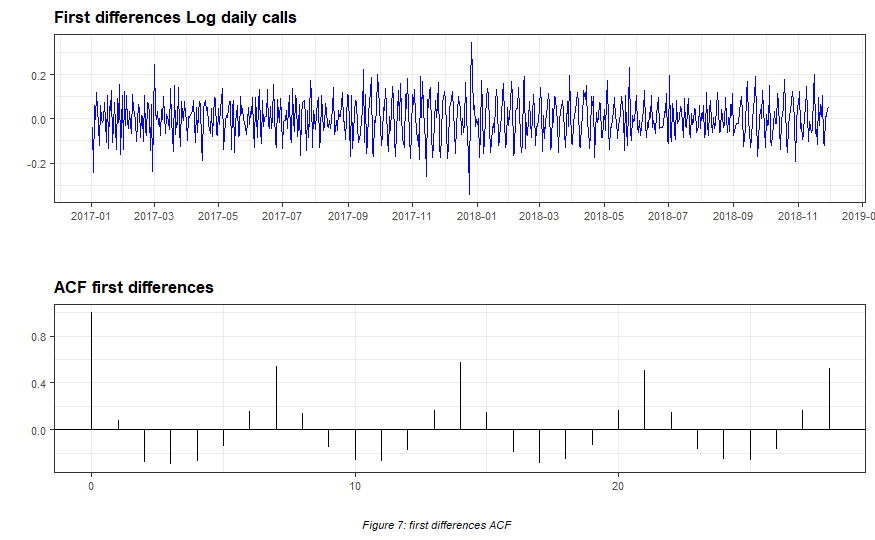

From *figures 6 and 7* it is can be concluded that a weekly seasonality exists in this time series with the ACF not showing a rapid convergence over time

## Detrending fitting a model

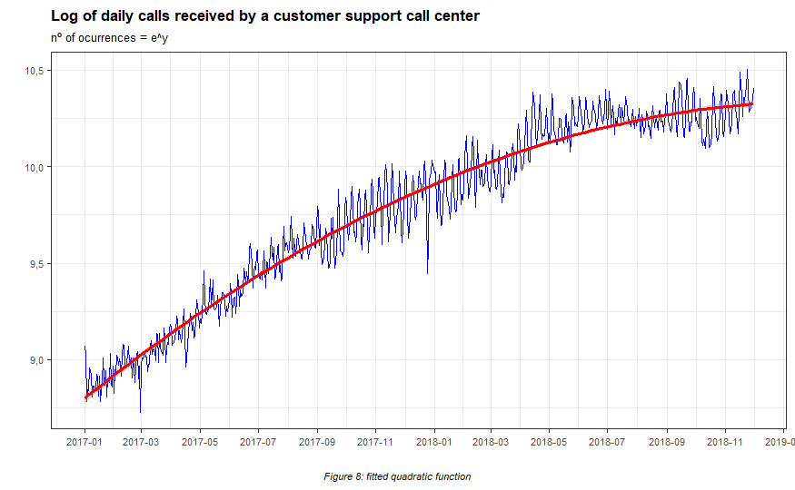

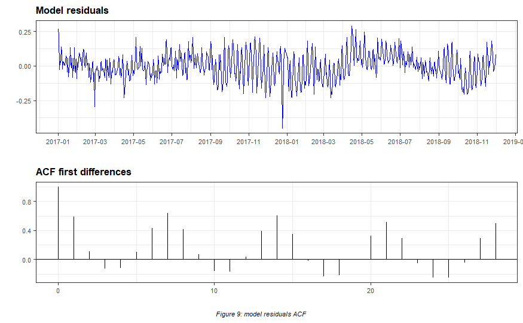